# Beyond Linearity

Adapting the Linear Model Framework for Non-Linear Patterns

Specialist Analytics Team (SAT)

# When Linear Regression Works

The Linearity Assumption

## Linear Models for Linear Effects

- Linear regression fits a straight line through data
- Assumes constant effect: each unit increase in $X$ changes $Y$ by the same amount
- Works when the relationship is linear

$$Y = \beta_0 + \beta_1X + \epsilon$$

## Linear Relationships in the Real World

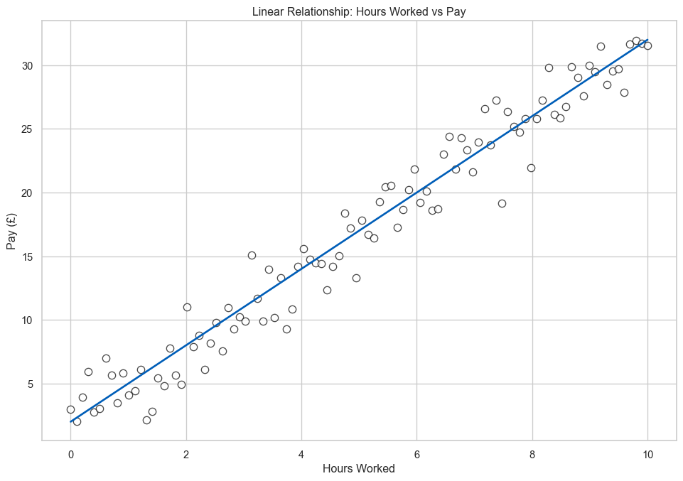

## But Real Data Isn’t Always Linear

- Growth curves (exponential, logistic)
- Binary outcomes (survived/died, yes/no)
- Count data (number of events)
- Bounded outcomes (proportions, rates)
- Curved relationships (U-shaped, S-shaped)

# The Problem with Forcing Linearity

When Straight Lines Don’t Fit

## Probability of Disease by Age

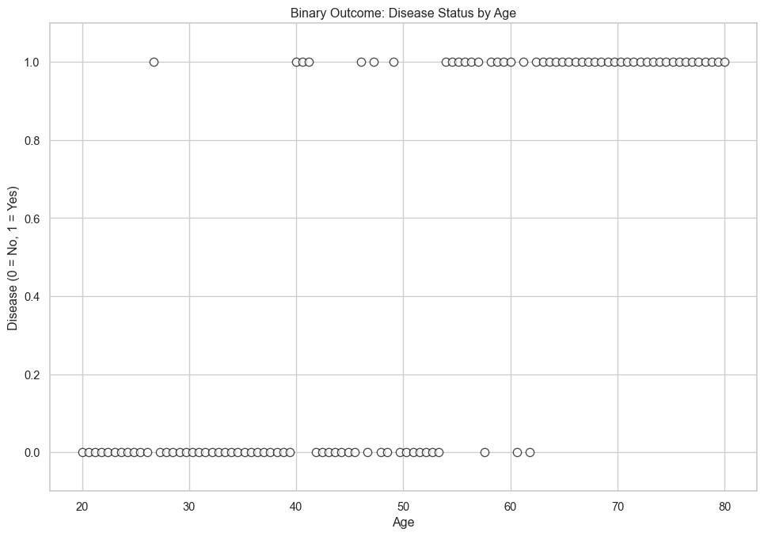

## Fitting a Straight Line Fails

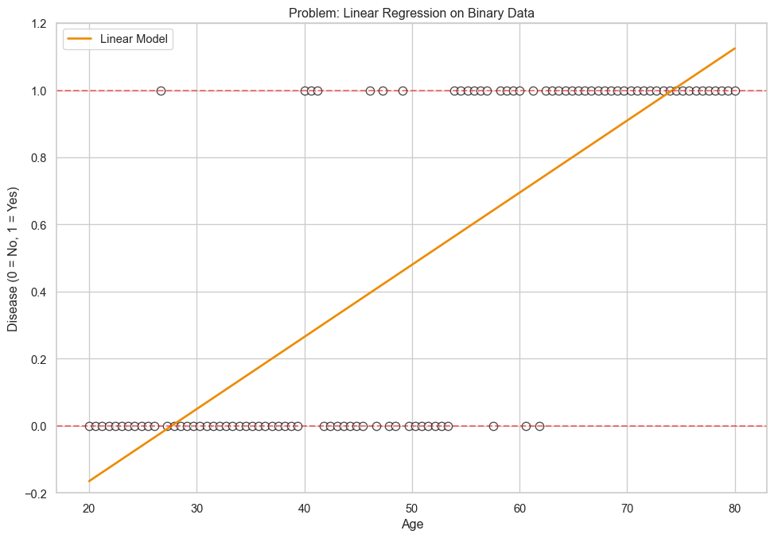

## The Problem is the Scale

- Linear regression assumes outcomes can take any value
- But many outcomes are constrained:
  - Probabilities must be between 0 and 1
  - Counts must be non-negative integers
  - Proportions are bounded
- Forcing a straight line violates these constraints

# Transform the Scale

Link Functions Make Non-Linear Data Linear

## The Core Insight

- Don’t force data onto a straight line
- Transform the scale so linear regression works
- Fit the line on the transformed scale
- Transform back to get predictions
- This is what link functions do.

## How Link Functions Work

- The link function connects the linear predictor to the outcome:
  1. Take your outcome $Y$ (bounded, binary, count, etc.)
  2. Apply a transformation that “stretches” or “squashes” the scale
  3. Fit a linear model on the transformed scale
  4. Transform predictions back to the original scale

## The Logit Link for Binary Outcomes

- For binary outcomes (0 or 1), we model the **log-odds**:

$$\log\left(\frac{p}{1-p}\right) = \beta_0 + \beta_1X$$

- Left side: log-odds (can be any value)
- Right side: linear predictor (can be any value)
- Transform back to get probability: $p = \frac{1}{1 + e^{-(\beta_0 + \beta_1X)}}$
- This is **logistic regression**.

## Visualising the Transformation

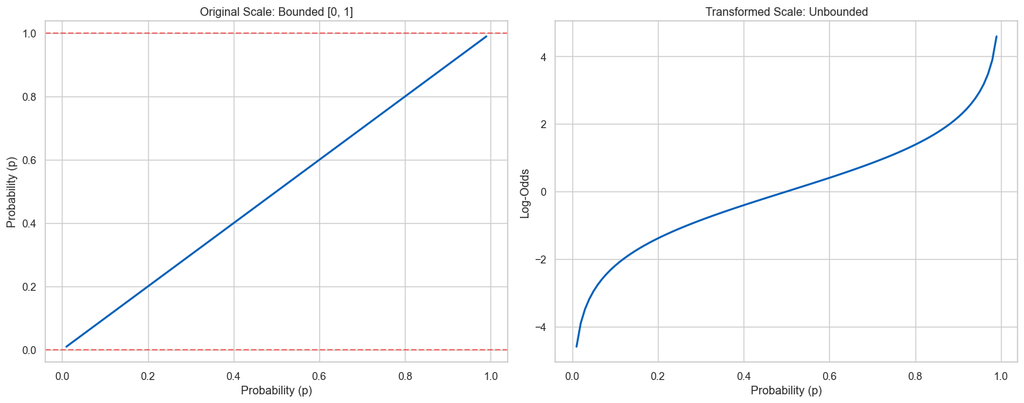

## Logistic Regression Fits an S-Curve

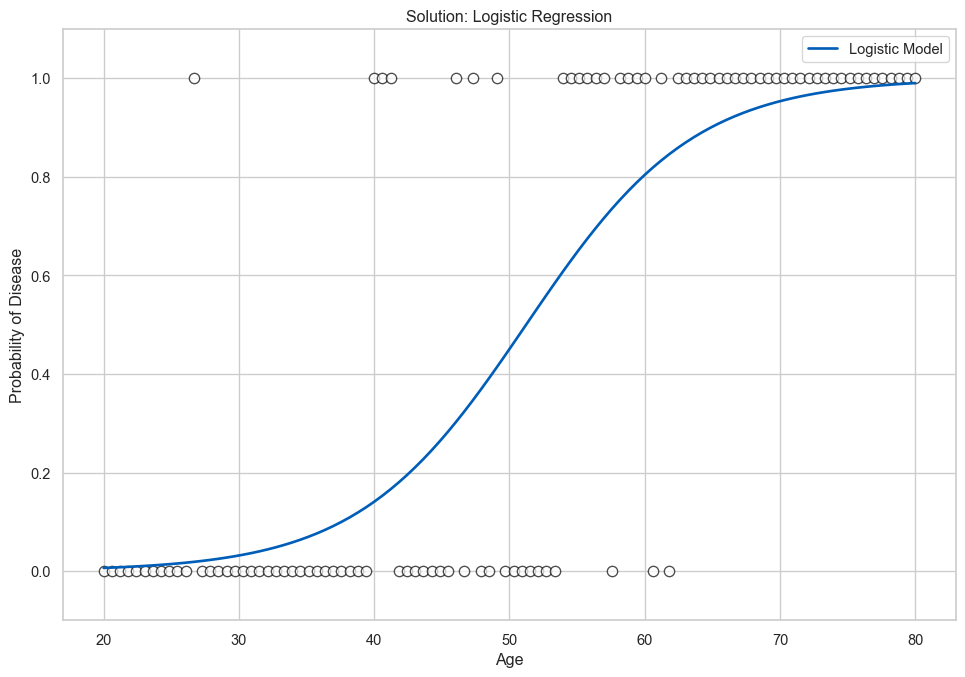

# Generalised Linear Models

The Family of Link Functions

## Different Outcomes Need Different Links

- **Binary outcomes** → Logit link → **Logistic regression**
- **Count data** → Log link → **Poisson regression**
- **Continuous positive** → Log link → **Log-linear models**
- **Proportions** → Logit link → **Beta regression**
- All follow the same pattern: transform, fit linear model, transform back.

## Poisson Regression Uses Log Link

- Model the log of the expected count:

$$\log(\text{E}[Y]) = \beta_0 + \beta_1X$$

- Left side: log of expected count (can be any value)
- Right side: linear predictor (can be any value)
- Transform back: $\text{E}[Y] = e^{\beta_0 + \beta_1X}$
- Predictions are always positive, matching count data.

# Wrapping Up

Key Takeaways

## What We’ve Learned

- Real data often doesn’t fit straight lines.
- Link functions transform non-linear problems into linear ones.
- Logistic regression (logit link) handles binary outcomes.
- Poisson regression (log link) handles count data.
- Linear regression isn’t limited to linear relationships.

## The Power of This Approach

- Simplicity - Same core idea (fit a line) works everywhere.
- Flexibility - Adapts to different data types and structures.
- Interpretability - Coefficients still represent effects.
- Extensibility - Once you know linear regression, you can learn anything.

## Further Learning

- StatQuest (Josh Starmer) - [Logistic Regression](https://www.youtube.com/watch?v=yIYKR4sgzI8)
- Andrew Gelman et al. - [Regression & Other Stories](https://users.aalto.fi/~ave/ROS.pdf)

## Thank You!

Contact:

Code & Slides:

[/NHS-South-Central-and-West/code-club](https://github.com/nhs-south-central-and-west/code-club)

… And don’t forget to give us your [feedback](https://forms.office.com/e/g9fnSVPRwE).